# ASI assessed exercise 2015/2016

## Question 1:

```python
import numpy as np
%matplotlib inline
import matplotlib.pyplot as plt
import pandas as pd
from math import *
import itertools
```

```python
white_wine_features_target = np.genfromtxt("winequality-white-header-removed.csv", dtype=np.float64, delimiter=';')
red_wine_features_target = np.genfromtxt("winequality-red-header-removed.csv", dtype=np.float64, delimiter=';')
```

## Question 2:

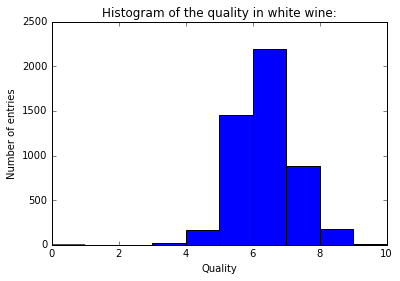

```python
plt.hist(white_wine_features_target[:, -1], bins=range(11))
plt.xlabel("Quality")
plt.ylabel("Number of entries")
plt.title("Histogram of the quality in white wine:")
plt.show()
```

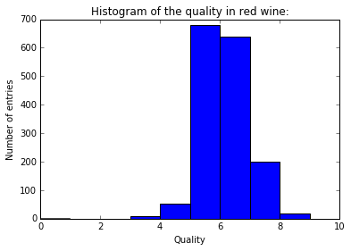

```python
plt.hist(red_wine_features_target[:,-1], bins = range(11))
plt.xlabel("Quality")
plt.ylabel("Number of entries")
plt.title("Histogram of the quality in red wine:")
plt.show()
```

## Question 3:

We have to be careful not to reguralize too much. Because then we would not predict low quality wine or high quality wine. The vast majority of the examples are graded 5,6 or 7. Our actions must differ depending on the type of algorithme that we use. With a linear regression, we should add more features (by increasing the polynomial order for example) because we need it to fit also the few cases of 4,8 and 9 With only 11 features and several thousands training examples, we'll likely only predict 5,6 or 7. With the K-nn, if we set K to a value like 20, we'll never predict 4,8 or 9 because it's very unlikely that 20 points with those labels are close to each other.

## Question 4: Linear regression

#### Question 4.a:

```python
np.random.shuffle(red_wine_features_target)
num_entries = red_wine_features_target.shape[0]
train = red_wine_features_target[:int(num_entries * 0.7)]
test = red_wine_features_target[int(num_entries * 0.7):]
```

#### Question 4.b:

```python
def features_targets(array):
    return array[:,:-1] , array[:,-1:]
```

```python
def extend(X, functions):
    list_of_new_values = []
    for function in functions:
        new_values = function(X)
        list_of_new_values.append(new_values)
    for new_values in list_of_new_values:
        X = np.concatenate((X, new_values), axis=1)

    lines_number = X.shape[0]
    X_with_ones = np.concatenate((np.array([[1] * lines_number]).T, X), axis=1)
    return X_with_ones
```

```python
def train_regressor(array, functions=[]):
    X, Y = features_targets(array)
    X = extend(X, functions)

    inverse = np.linalg.pinv(X.T.dot(X))
    A = inverse.dot(X.T).dot(Y)
    return A
```

```python
A = train_regressor(train)
```

#### Question 4.c:

```python
def predict_regressor(array, A, functions=[]):
    new_X, Y = features_targets(array)
    new_X = extend(new_X, functions)
    return new_X.dot(A), Y
```

```python
def mse(predictions, expected):
    size = predictions.shape[0]
    errors = predictions - expected
    error = errors.T.dot(errors)
    return error[0, 0] / size
```

```python
predictions, expectations = predict_regressor(test, A)
```

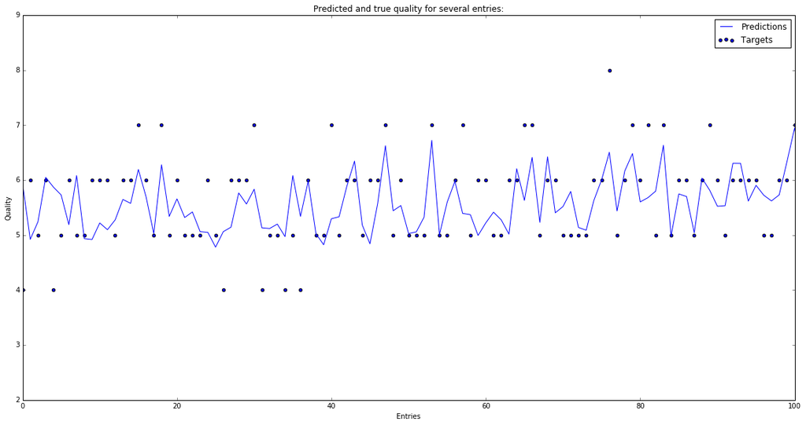

```python
plt.figure(figsize=(20, 10))
plt.plot(predictions, label = "Predictions")
plt.scatter(range(len(test)),expectations, label = "Targets")
plt.xlim((0,100))
plt.xlabel("Entries")
plt.ylabel("Quality")
plt.title("Predicted and true quality for several entries:")
plt.legend()
plt.show()
```

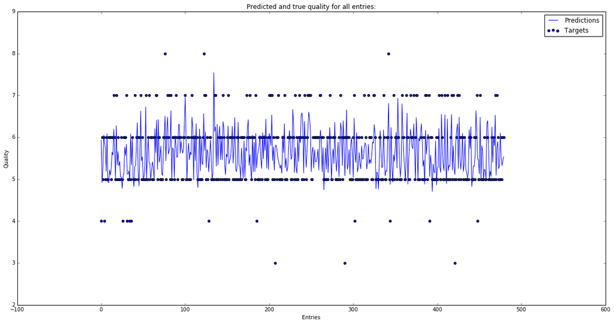

```python
plt.figure(figsize=(20, 10))
plt.plot(predictions, label = "Predictions")
plt.scatter(range(len(test)),expectations, label = "Targets")
plt.xlabel("Entries")
plt.ylabel("Quality")
plt.title("Predicted and true quality for all entries:")
plt.legend()
plt.show()
```

```python
mse_ = mse(predictions, expectations)
```

```python
mse_
```

```
0.43504643165570323
```

#### Question 4.d:

Since we measure the performance of our model with a mean square error, a good way to check if our model performs well is to compare it to naive predictions. So we could predict every time the mean of the quality colomn and do a mean square error. Then we compare the "naïve" model and the linear model. Doing this is actually comparing the mse of our linear model to the variance of the "Quality" colomn.

#### Question 4.e:

```python
def variance(values):
    size = values.shape[0]
    ones = np.array([[1] * size])
    mean = (ones.dot(values) / size)[0, 0]
    distance_to_mean = ones.T * mean - values
    variance_ = (distance_to_mean.T.dot(distance_to_mean) / size)[0, 0]
    return variance_
```

```python
variance_ = variance(expectations)
```

```python
variance_
```

```
0.63520399305555542
```

```python
print("Our model is", int((variance_ - mse_)*100/variance_), "% better than the mean prediction.")
```

```
Our model is 31 % better than the mean prediction.
```

Our linear model perform quite well. The MSE is substentially better than the variance. It means that our model brings value to the problem. And it's a path worth exploring if we want to get an even better MSE. That's why we'll try now a linear model of higher order.

#### To go further: trying polynomials

Here we test the linear regression with an order of 3. Since we have 11 features, trying a real order 3 would result in 11+11^2+11^3 = 1463 features. So a bit too much. Instead we'll try with x, x^2, x^3 for each feature x. So a total of 33 features.

```python
functions = [lambda x: x*x, lambda x: x*x*x]
A = train_regressor(train,functions)
predictions, expectations = predict_regressor(test, A, functions)
```

```python
mse_ = mse(predictions, expectations)
```

```python
mse_
```

```
0.41921251072474519
```

```python
variance_ = variance(expectations)
```

```python
variance_
```

```
0.63520399305555542
```

```python
print("Our model is", int((variance_ - mse_)*100/variance_), "% better than the mean prediction.")
```

```
Our model is 34 % better than the mean prediction.
```

It seems that higher polynomials does decrease the MSE. It shows that there is still some other features that we can extract. It would be worth spending some time on features selection with the help of cross-validation.

## Question 5: Regularized linear regression

#### Question 5.a:

```python
def train_regularized_regressor(array, functions=[], lambda_=0):
    X, Y = features_targets(array)
    X = extend(X, functions)

    I = np.identity(X.shape[1])
    I[0, 0] = 0

    inverse = np.linalg.pinv(X.T.dot(X) + lambda_ * I)
    A = inverse.dot(X.T).dot(Y)
    return A
```

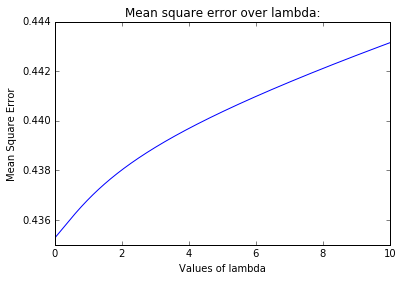

```python
extreme = [0,10]
nb_points = 1001
mse_list = []
for lambda_ in np.linspace(extreme[0],extreme[1],nb_points):
    A = train_regularized_regressor(train, lambda_ = lambda_)
    predictions, Y_test = predict_regressor(test,A)
    mse_list.append(mse(predictions, Y_test))

plt.plot(np.linspace(extreme[0],extreme[1],nb_points),mse_list)
plt.xlabel("Values of lambda")
plt.ylabel("Mean Square Error")
plt.title("Mean square error over lambda:")
plt.show()
```

#### Question 5.b:

We cannot trust this kind of practice because the result would fit well on the test data, but it doesn't mean that our model can be easily generalized. In the end, we can always find a model that fit perfectly the test data. But as soon as we change the test data, everything will be different and the mse will change(and will likely be worst). We need to test it on more data to improve our confidence in the model.

#### Question 5.c:

```python
def cross_validation(data, train_function, prediction_function, nb_slices = 10):
    np.random.shuffle(data)
    intervals = np.linspace(0, len(data), nb_slices)
    indexes = [int(i) for i in intervals]

    mse_list = []
    for i in range(nb_slices - 1):

        # We create the train and the test data
        test = data[indexes[i]:indexes[i + 1]]
        train = np.concatenate((data[:indexes[i]], data[indexes[i + 1]:]), axis=0)

        # Now we train and predict
        A = train_function(train)
        prediction, targets = prediction_function(test, A)

        current_mse = mse(prediction, targets)
        mse_list.append(current_mse)

    mean = sum(mse_list) / len(mse_list)
    return mean
```

```python
def find_best_lambda_cross_validation(data, functions=[]):
    extreme = [0, 2]
    nb_points = 1000
    mse_list = []
    for lambda_ in np.linspace(extreme[0], extreme[1], nb_points):
        def regressor(x):
            return train_regularized_regressor(x, functions, lambda_)

        def predict(x, A):
            return predict_regressor(x, A, functions)

        current_mse = cross_validation(data, regressor, predict, 10)

        mse_list.append(current_mse)

    m = min(mse_list)
    idx = mse_list.index(m)
    best_lambda = np.linspace(extreme[0], extreme[1], nb_points)[idx]
    plt.plot(np.linspace(extreme[0], extreme[1], nb_points), mse_list)
    plt.xlabel("Values of lambda")
    plt.ylabel("Mean Square Error")
    plt.title("Mean square error over lambda:")
    plt.show()
    print('Best mse:', m, "\t Best lambda:", best_lambda)
    return m, best_lambda
```

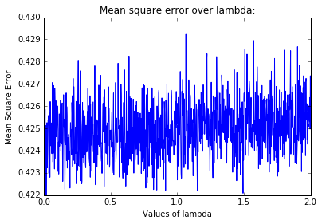

```
Best mse: 0.422012922509 	 Best lambda: 0.018018018018
```

```python
mse_ , best_lambda = find_best_lambda_cross_validation(red_wine_features_target)
```

#### Question 5.d:

We did not test our linear regression model with cross validation. And, because we don't want to compare two values obtains with different levels of accuracy, we'll do a cross-validation with the linear regression.

```python
mse_linear_regression = cross_validation(red_wine_features_target, train_regressor, predict_regressor, 10)
```

```python
mse_linear_regression
```

```
0.42531900581053877
```

The mse with the linear regression is 0.425 and the one with a regularization term is 0.422 which is slightly better. But it would be interesting to know how well perform a linear regression of order 3 with a regularization term.

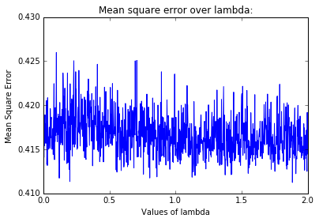

```
Best mse: 0.411237076046 	 Best lambda: 1.88388388388
```

```python
mse_order3 , best_lambda_order3 = find_best_lambda_cross_validation(red_wine_features_target, functions)
```

we get 0.411 which is better than the 0.422 given by a regularized linear regression of order 1. It tells us that we can get a better improvement by increasing the order of the features. Comforting the idea of features selection.

## Question 6: Classification

#### Question 6.a:

A limitation of the regression is that it's possible for a feature to influence the "Quality" but not in the linear sense. It could be a log or an exponential for all we know. And classification algorithms are better at handling this kind of features.

#### Question 6.b:

For the following questions, I will use a naïve bayes classifier. One of the disadvantages of this algorithm is that the classifier assume that all the features are independants. And it's not the case at all here. We have for example "free sulfur dioxide" and "total sulfur dioxide". Just by the name, we know that they're related. It's the same for "fixed acidity" and "pH" since the pH is a measure of acidity.  
On the other hand, with naïve bayes, the training and testing part are both really fast. Which makes it interesting if it will be heavely used to predict something in the future. Or even do a lot of cross-validations to find the best set of features.

#### Question 6.c:

Since there is no parameter to tune, we'll replace this step by data pre-processing. In our case, we will do a cross-validation for each set of features that we select. Since we have 11 features, we'll try the different 2^11 set of possible features.

#### Question 6.d:

```python
# This will allow us to select features by giving the index of the features to keep.
def getAllPossibilities(lenght = 11):
    result = []
    for booleans in itertools.product([False, True],repeat=lenght):
        result.append(tuple(i for i, take in enumerate(booleans) if take))
    return result[1:] # Because the first one is empty

getAllPossibilities(3)
```

```
[(2,), (1,), (1, 2), (0,), (0, 2), (0, 1), (0, 1, 2)]
```

```python
# selection is a tuple indexes indicating which features to keep.
def select_features(data, selection):
    selection +=(11,)
    return data[:,selection]

# Here we only keep the features 0, 2, 8 and 10 corresponding
# to the fixed acidity, the citric acid, the pH and the alcohol.
select_features(red_wine_features_target, (0,2,8,10))
```

```
array([[  1.22000000e+01,   4.90000000e-01,   3.13000000e+00,
          1.04000000e+01,   5.00000000e+00],
       [  7.10000000e+00,   1.00000000e-02,   3.40000000e+00,
          1.09000000e+01,   6.00000000e+00],
       [  5.00000000e+00,   1.00000000e-02,   3.70000000e+00,
          1.40000000e+01,   6.00000000e+00],
       ...,
       [  9.90000000e+00,   4.50000000e-01,   3.39000000e+00,
          9.40000000e+00,   5.00000000e+00],
       [  7.50000000e+00,   5.60000000e-01,   3.21000000e+00,
          1.16000000e+01,   6.00000000e+00],
       [  7.50000000e+00,   2.00000000e-02,   3.36000000e+00,
          1.05000000e+01,   6.00000000e+00]])
```

If for a given class, we have only one example, then the variance will be zero and cacluating the gaussian will not be possible. That is why our decision will be to remove this class of the set of possible classes.

```python
def delete_zero_variance(dictionary):
    for key, value in dictionary.items():
        if value[0][0][1] == 0:
            dictionary.pop(key, None)
    return dictionary
```

```python
# The object that is returned is a dictionary.
# The class are the keys
# The values are tuples.
# The first element of this tuple is a list containing all the variances and means
# The second element of this tuple is the number of examples with this class
def naive_bayes_train(data):
    lenght = data.shape[1]
    df = pd.DataFrame(data)

    # We group by the quality of the wine
    grouped = df.groupby([lenght - 1])

    # Now we get the variances and means to create later the gaussian distributions
    gaussians = dict()
    for quality, set in grouped: # for each class
        means = list(set.mean())[:-1]
        variances = list(set.var())[:-1]

        # We need the prior, but since it's simpler for computation, we'll take the
        # prior multiplied by the number of entities in the training set (constant)
        count = set.shape[0]

        # We create a list of gaussian distributions
        a = []
        for i in range(lenght - 1):
            a.append((means[i], variances[i]))
        gaussians[int(quality)] = (a, count)

    # we delete the classes with a null variance
    gaussians = delete_zero_variance(gaussians)
    return gaussians
```

```python
def gaussian(x, mean, variance):
    exponential = exp(-(x - mean) ** 2 / (2 * variance))

    result = exponential / (sqrt(variance * 2 * pi))

    return result
```

```python
def naive_bayes_predict(data, table):
    lenght = data.shape[1]
    X, Y = features_targets(data)
    predictions = []
    for row in X:
        best_class_and_score = (0, 0)
        for key, value in table.items(): # for each class

            # We get the score given by each gaussian
            scores = [gaussian(row[i], value[0][i][0], value[0][i][1]) for i in range(lenght-1)]

            # We multipie the results of the gaussians and the prior
            score = np.prod(scores)*value[1]

            # We select the class with the highest score
            if score > best_class_and_score[1]:
                best_class_and_score = (key, score)

        predictions.append(best_class_and_score)

    return np.array([prediction[0] for prediction in predictions]).T, Y
```

Even if the question ask for the best classification accuracy, I do believe that the mse should be employed. Let's say we predict a quality of 4 and the true quality was 9. With the 0/1 loss, it's the same as if we had predicted a quality of 8. That's why we will still use mse for cross-validation.

```python
# First we get all the combinaisons of features
list_of_features_sets = getAllPossibilities()
list_of_mse = []
for i, features_set in enumerate(list_of_features_sets):
    print(i, end = "\r")

    # We select only the features that we want
    new_dataset = select_features(red_wine_features_target, features_set)
    new_mse = cross_validation(new_dataset, naive_bayes_train, naive_bayes_predict)
    list_of_mse.append(new_mse)

results = zip(list_of_features_sets,list_of_mse)
sorted_results = sorted(results, key = lambda x: x[1])
```

```python
sorted_results[:5]
```

```
[((0, 4, 5, 8), 0.78413635498000389),
 ((4, 5, 9), 0.78417867496138305),
 ((2, 5, 6, 8, 9), 0.78420336161718762),
 ((0, 2, 3, 4, 5, 6, 7, 9), 0.78421394161253233),
 ((1, 4, 5, 6, 7, 9), 0.78421746827764727)]
```

So the best mse is 0.78. It is obtained with the following set of features: fixed acidity, chlorides, free sulfur dioxide and pH. Not better than the linear regression. We will now do the same cross-validation to find the best 0/1 loss:

```python
# The results are in percentage.
def get_classification_accuracy(predictions, targets):
    assert len(predictions) == len(targets)

    nb_exact_guesses = 0
    for prediction, target in zip(predictions, targets):
        if prediction == target:
            nb_exact_guesses += 1

    accuracy_percentage = nb_exact_guesses * 100 / len(predictions)
    return accuracy_percentage
```

```python
def cross_validation_01loss(data, train_function, prediction_function, nb_slices = 10):
    np.random.shuffle(data)
    intervals = np.linspace(0, len(data), nb_slices)
    indexes = [int(i) for i in intervals]

    loss_list = []
    for i in range(nb_slices - 1):

        # We create the train and the test data
        test = data[indexes[i]:indexes[i + 1]]
        train = np.concatenate((data[:indexes[i]], data[indexes[i + 1]:]), axis=0)

        # Now we train and predict
        A = train_function(train)
        prediction, targets = prediction_function(test, A)

        current_loss = get_classification_accuracy(prediction, targets)
        loss_list.append(current_loss)

    mean = sum(loss_list) / len(loss_list)
    return mean
```

```python
list_of_features_sets = getAllPossibilities()
list_of_loss = []
for i, features_set in enumerate(list_of_features_sets):
    print(i, end = "\r")
    new_dataset = select_features(red_wine_features_target, features_set)
    new_loss = cross_validation_01loss(new_dataset, naive_bayes_train, naive_bayes_predict)
    list_of_loss.append(new_loss)

results = zip(list_of_features_sets,list_of_loss)
sorted_results = sorted(results, key = lambda x: -x[1])
```

```python
sorted_results[:4]
```

```
[((1, 5, 6, 9, 10), 60.16631752682029),
 ((1, 6, 9, 10), 59.72830571954549),
 ((1, 6, 7, 9, 10), 58.91470407753021),
 ((1, 6, 8, 9, 10), 58.7870388003696)]
```

So with only 5 features, we can get a precision of 60.16 %. It means that only a few of those 11 features are really important. If we try to get the 0/1 loss with all features, we get:

```python
np.random.shuffle(red_wine_features_target)
num_entries = red_wine_features_target.shape[0]
train = red_wine_features_target[:int(num_entries * 0.7)]
test = red_wine_features_target[int(num_entries * 0.7):]
```

```python
gaussians = naive_bayes_train(train)
predictions, targets = naive_bayes_predict(test, gaussians)
get_classification_accuracy(predictions, targets)
```

```
59.375
```

By choosing the right features, our naive bayes algorithm has increase its accuracy by nearly 1%.

#### Question 6.e:

```python
def get_confusion_matrix(predictions, targets):
    l = len(targets)
    assert len(predictions) == l

    lower = int(min((min(predictions), min(targets))))
    upper = int(max((max(predictions), max(targets))))
    nb_classes = upper + 1 - lower

    confusion_matrix = np.zeros((nb_classes, nb_classes))
    for prediction, target in zip(predictions, targets):
        confusion_matrix[int(target) - lower, int(prediction)-lower] += 1

    return confusion_matrix
```

```python
new_dataset = select_features(red_wine_features_target, sorted_results[0][0])
```

```python
np.random.shuffle(new_dataset)
num_entries = new_dataset.shape[0]
train = new_dataset[:int(num_entries * 0.7)]
test = new_dataset[int(num_entries * 0.7):]
```

```python
gaussians = naive_bayes_train(train)
predictions, targets = naive_bayes_predict(test, gaussians)
```

```python
mse(predictions, targets)
```

```
0.83333333333333337
```

```python
get_classification_accuracy(predictions, targets)
```

```
61.25
```

```python
get_confusion_matrix(predictions, targets)
```

```
array([[   0.,    2.,    1.,    0.,    0.,    0.],
       [   1.,    1.,   13.,    5.,    0.,    0.],
       [   0.,    5.,  150.,   57.,    2.,    0.],
       [   0.,    4.,   46.,  122.,    7.,    0.],
       [   0.,    0.,    5.,   33.,   21.,    0.],
       [   0.,    0.,    0.,    4.,    1.,    0.]])
```

#### Question 6.f:

-Since naive bayes assume that the features are independant, we could try to do a PCA before training and testing. Though i'm not sure at all of the quality of the results.  
-In our naive bayes, we assumed that the probability distributions were gaussians. But it may not be the case at all. In order to model better the data, we could plot histograms of features given a "Quality" grade. This way, we can check if the distribution really look like a gaussian or not. If they're not, we could try normal distributions or enven uniform distributions  
-Also, we saw that regularized linear regression gave good results(even at order 3). In the same way that we selected features in the part 6, we could select features for a regularized linear regression and certainly get a better result than before.  
-We could try other algorithms: decision trees, K-nn, SVM.